# Nathan_Njonge_IP_R_Fundamentals

Nathan_Njonge

7/2/2021

### Research Question

A Kenyan entrepreneur has created an online cryptography course and would want to advertise it on her blog. She currently targets audiences originating from various countries. In the past, she ran ads to advertise a related course on the same blog and collected data in the process. She would now like to employ your services as a Data Science Consultant to help her identify which individuals are most likely to click on her ads.

### Metric for success

This project will be successful when we correctly identify which individuals are most likely to click on the ads.

### Experimental design taken

1. Specify the research question.
2. Perform Exploratory Data Analysis- Univariate and Bivariate
3. Make conclusions and recommendations

### Data Relevance

1. Daily.Time.Spent.on.Site -> This refers to the duration a user spends on the site.
2. Age -> This refers to the age of the user
3. Area.Income
4. Daily.Internet.Usage -> this refers to the duration a user spends on the internet
5. Ad.Topic.Line -> this refers to the context of the ad
6. City -> this represents the city of the user
7. Male -> this identifys whether the user is male or female
8. Country -> this represents the country of the user.
9. Timestamp
10. Clicked.on.Ad -> this represents whether the user clicked on the ad or not.

```r
# view the top of our dataset
dataset <- read.csv("http://bit.ly/IPAdvertisingData")
head(dataset)
```

```
##   Daily.Time.Spent.on.Site Age Area.Income Daily.Internet.Usage
## 1                    68.95  35    61833.90               256.09
## 2                    80.23  31    68441.85               193.77
## 3                    69.47  26    59785.94               236.50
## 4                    74.15  29    54806.18               245.89
## 5                    68.37  35    73889.99               225.58
## 6                    59.99  23    59761.56               226.74
##                           Ad.Topic.Line           City Male    Country
## 1    Cloned 5thgeneration orchestration    Wrightburgh    0    Tunisia
## 2    Monitored national standardization      West Jodi    1      Nauru
## 3      Organic bottom-line service-desk       Davidton    0 San Marino
## 4 Triple-buffered reciprocal time-frame West Terrifurt    1      Italy
## 5         Robust logistical utilization   South Manuel    0    Iceland
## 6       Sharable client-driven software      Jamieberg    1     Norway
##             Timestamp Clicked.on.Ad
## 1 2016-03-27 00:53:11             0
## 2 2016-04-04 01:39:02             0
## 3 2016-03-13 20:35:42             0
## 4 2016-01-10 02:31:19             0
## 5 2016-06-03 03:36:18             0
## 6 2016-05-19 14:30:17             0
```

```r
# view the bottom of our dataset
tail(dataset)
```

```
##      Daily.Time.Spent.on.Site Age Area.Income Daily.Internet.Usage
## 995                     43.70  28    63126.96               173.01
## 996                     72.97  30    71384.57               208.58
## 997                     51.30  45    67782.17               134.42
## 998                     51.63  51    42415.72               120.37
## 999                     55.55  19    41920.79               187.95
## 1000                    45.01  26    29875.80               178.35
##                             Ad.Topic.Line          City Male
## 995         Front-line bifurcated ability  Nicholasland    0
## 996         Fundamental modular algorithm     Duffystad    1
## 997       Grass-roots cohesive monitoring   New Darlene    1
## 998          Expanded intangible solution South Jessica    1
## 999  Proactive bandwidth-monitored policy   West Steven    0
## 1000      Virtual 5thgeneration emulation   Ronniemouth    0
##                     Country           Timestamp Clicked.on.Ad
## 995                 Mayotte 2016-04-04 03:57:48             1
## 996                 Lebanon 2016-02-11 21:49:00             1
## 997  Bosnia and Herzegovina 2016-04-22 02:07:01             1
## 998                Mongolia 2016-02-01 17:24:57             1
## 999               Guatemala 2016-03-24 02:35:54             0
## 1000                 Brazil 2016-06-03 21:43:21             1
```

```r
dim(dataset)
```

```
## [1] 1000   10
```

```r
# our dataset has 1000 rows and 10 columns
```

Our Dataset has 1000 rows and 10 columns.

```r
# check for total in each columns null values
colSums(is.na(dataset))
```

```
## Daily.Time.Spent.on.Site                      Age              Area.Income
##                        0                        0                        0
##     Daily.Internet.Usage            Ad.Topic.Line                     City
##                        0                        0                        0
##                     Male                  Country                Timestamp
##                        0                        0                        0
##            Clicked.on.Ad
##                        0
```

```r
# find any duplicated rows in our dataset
duplicated_rows <- dataset[duplicated(dataset),]
duplicated_rows
```

```
##  [1] Daily.Time.Spent.on.Site Age                      Area.Income
##  [4] Daily.Internet.Usage     Ad.Topic.Line            City
##  [7] Male                     Country                  Timestamp
## [10] Clicked.on.Ad
## <0 rows> (or 0-length row.names)
```

```r
# overview of the dataset
summary(dataset)
```

```
##  Daily.Time.Spent.on.Site      Age         Area.Income    Daily.Internet.Usage
##  Min.   :32.60            Min.   :19.00   Min.   :13996   Min.   :104.8
##  1st Qu.:51.36            1st Qu.:29.00   1st Qu.:47032   1st Qu.:138.8
##  Median :68.22            Median :35.00   Median :57012   Median :183.1
##  Mean   :65.00            Mean   :36.01   Mean   :55000   Mean   :180.0
##  3rd Qu.:78.55            3rd Qu.:42.00   3rd Qu.:65471   3rd Qu.:218.8
##  Max.   :91.43            Max.   :61.00   Max.   :79485   Max.   :270.0
##  Ad.Topic.Line          City                Male         Country
##  Length:1000        Length:1000        Min.   :0.000   Length:1000
##  Class :character   Class :character   1st Qu.:0.000   Class :character
##  Mode  :character   Mode  :character   Median :0.000   Mode  :character
##                                        Mean   :0.481
##                                        3rd Qu.:1.000
##                                        Max.   :1.000
##   Timestamp         Clicked.on.Ad
##  Length:1000        Min.   :0.0
##  Class :character   1st Qu.:0.0
##  Mode  :character   Median :0.5
##                     Mean   :0.5
##                     3rd Qu.:1.0
##                     Max.   :1.0
```

# Handling outliers

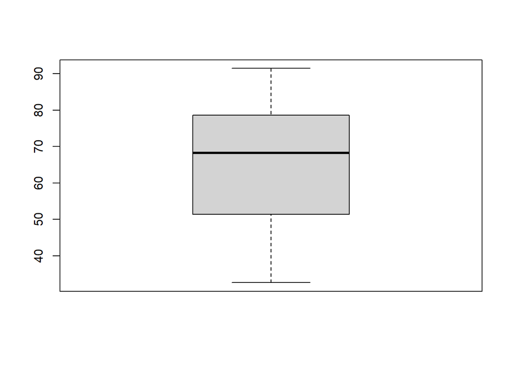

```r
# checking for outliers on time spent on site
boxplot(dataset$Daily.Time.Spent.on.Site)
```

```r
# there appears to be no outliers in the daily time spent on site column
```

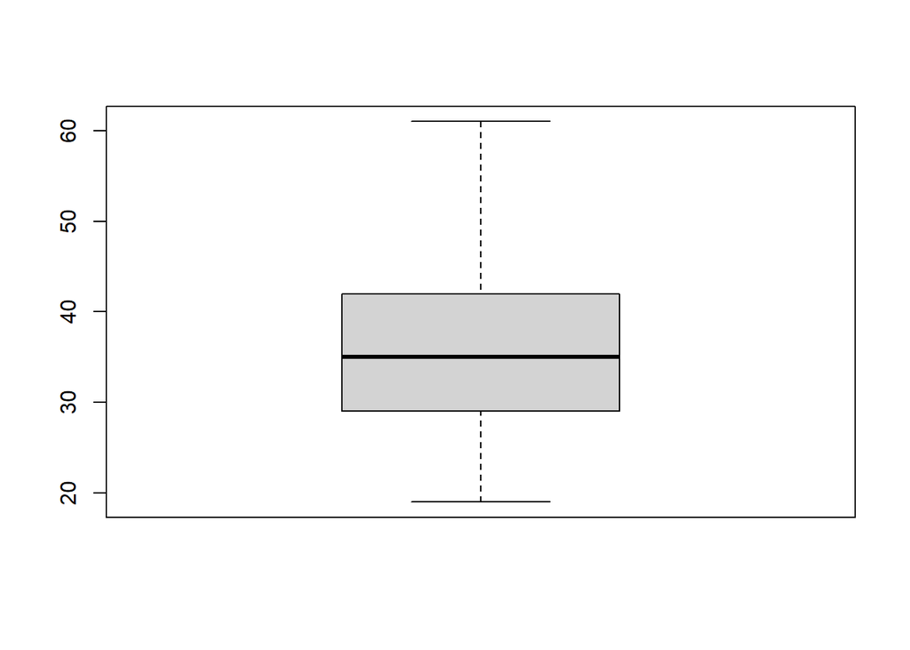

```r
# checking for outliers in age column
boxplot(dataset$Age)
```

```r
# There appears to be no presence of outliers in the age column.
```

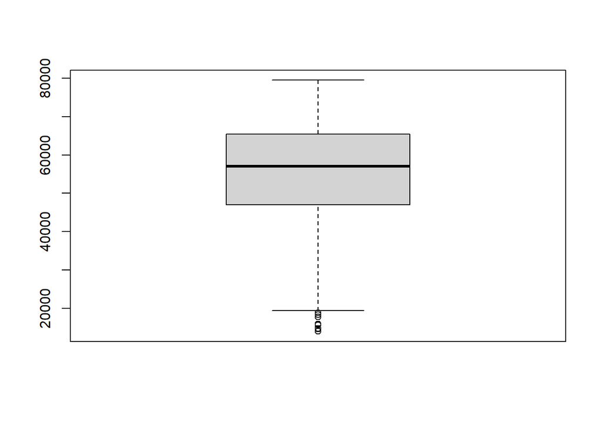

```r
# checking for outliers in area income
boxplot(dataset$Area.Income)
```

```r
# viewing the exact outliers in the column rows
boxplot.stats(dataset$Area.Income)$out
```

```
## [1] 17709.98 18819.34 15598.29 15879.10 14548.06 13996.50 14775.50 18368.57
```

```r
# the resulting outliers are as a result of the area income that was below average
```

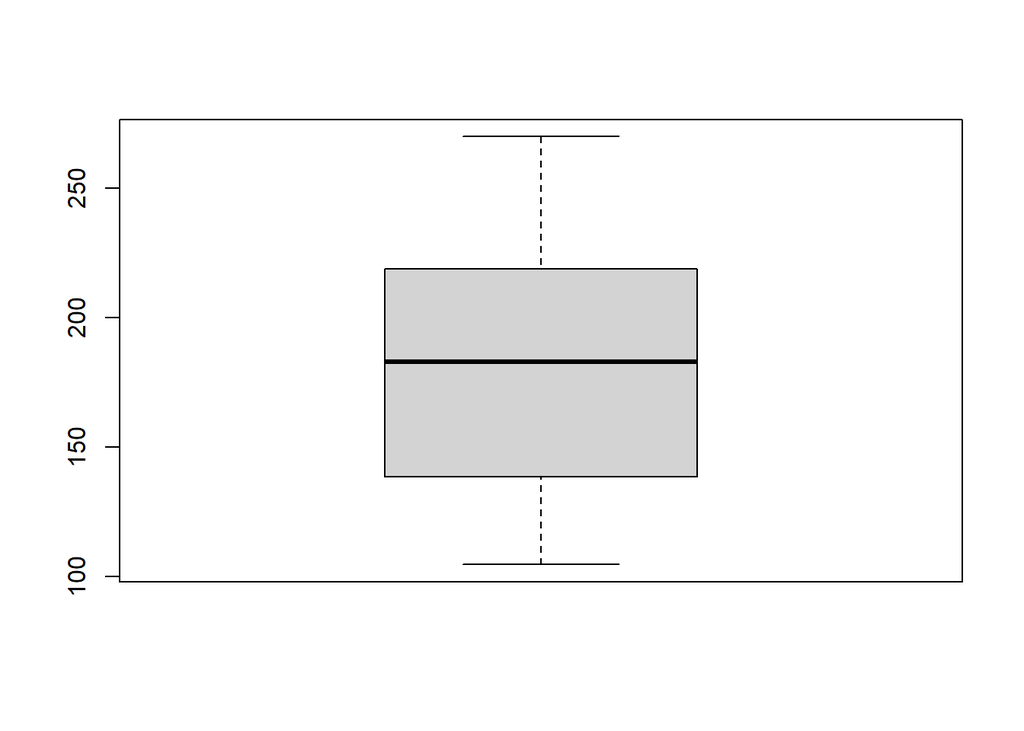

```r
# checking for outliers in daily internet usage column
boxplot(dataset$Daily.Internet.Usage)
```

```r
# There appears to be no outliers in the daily internet usage column
```

## Univariate Graphical Exploratory Data Analysis

### 1. Measures of Central Tendency

#### Daily Time Spent on Site

```r
# mean
mean(dataset$Daily.Time.Spent.on.Site)
```

```
## [1] 65.0002
```

> mean time spent on site on a daily is 65.0002

```r
# median
median(dataset$Daily.Time.Spent.on.Site)
```

```
## [1] 68.215
```

> Median for the average time spent on site is 68

```r
# mode
getmode <- function(v) {
   uniqv <- unique(v)
   uniqv[which.max(tabulate(match(v, uniqv)))]
}

getmode(dataset$Daily.Time.Spent.on.Site)
```

```
## [1] 62.26
```

> The most common duration spent on site is 62.26

#### Age

```r
# mean of age
mean(dataset$Age)
```

```
## [1] 36.009
```

> The mean age was 36 years

```r
# median
median(dataset$Age)
```

```
## [1] 35
```

> The median age was 35 years

```r
# mode
getmode(dataset$Age)
```

```
## [1] 31
```

> The most frequent age was 31 years

#### Area Income

```r
# mean of area income
mean(dataset$Area.Income)
```

```
## [1] 55000
```

> The mean for the area income is 55000

```r
# median of area income
median(dataset$Area.Income)
```

```
## [1] 57012.3
```

> The median for the area income was 57012

```r
# mode of area income
getmode(dataset$Area.Income)
```

```
## [1] 61833.9
```

> The modal income for the area income was 61834

#### Daily internet usage

```r
# mean of daily internet usage
mean(dataset$Daily.Internet.Usage)
```

```
## [1] 180.0001
```

> The mean of daily internet usage is 180

```r
# median of daily internet usage
median(dataset$Daily.Internet.Usage)
```

```
## [1] 183.13
```

> The median of daily internet usage is 183

```r
# mode
getmode(dataset$Daily.Internet.Usage)
```

```
## [1] 167.22
```

> The mode of daily internet usage was 167.22

## 2. Measures of Dispersion

#### Daily time spent on site

```r
# min of daily time spent on site
min(dataset$Daily.Time.Spent.on.Site)
```

```
## [1] 32.6
```

> The minimum daily time spent on site was 32.6

```r
# max of daily time spent on site
max(dataset$Daily.Time.Spent.on.Site)
```

```
## [1] 91.43
```

> The maximum daily time spent on site was 91.43

```r
# range of daily time spent on site
range(dataset$Daily.Time.Spent.on.Site)
```

```
## [1] 32.60 91.43
```

> The range of daily time spent on site was 32.60 on the minimum and 91.43 on the maximum

```r
# quantiles for the daily time spent on site
quantile(dataset$Daily.Time.Spent.on.Site)
```

```
##      0%     25%     50%     75%    100%
## 32.6000 51.3600 68.2150 78.5475 91.4300
```

> The 25% quantile we have 51.36 and the 75% quantile we have 78.55

```r
# variance of daily time spent on site
var(dataset$Daily.Time.Spent.on.Site)
```

```
## [1] 251.3371
```

> The variance for the daily time spent on site was 251.34

```r
# standard deviation for the daily time spent on site
sd(dataset$Daily.Time.Spent.on.Site)
```

```
## [1] 15.85361
```

> The standard deviation for the daily time spent on site is 15.85

#### Age

```r
# min of Age
min(dataset$Age)
```

```
## [1] 19
```

> The minimum age was 19 years

```r
# max of Age
max(dataset$Age)
```

```
## [1] 61
```

> The maximum age was 61 years old

```r
range(dataset$Age)
```

```
## [1] 19 61
```

> The range for the age was 19 years the youngest and 61 years the oldest

```r
# quantile for the age
quantile(dataset$Age)
```

```
##   0%  25%  50%  75% 100%
##   19   29   35   42   61
```

> The 25% quantile has 29 years and the 75% quantile has 42 years.

```r
# variance of age
var(dataset$Age)
```

```
## [1] 77.18611
```

> The variance of the age was 77.19

```r
# standard deviation of the age
sd(dataset$Age)
```

```
## [1] 8.785562
```

> The standard deviation of the age was 8.79

#### Area Income

```r
# min of area income
min(dataset$Area.Income)
```

```
## [1] 13996.5
```

> The minimum of the area income is 13996.5

```r
# max of area income
max(dataset$Area.Income)
```

```
## [1] 79484.8
```

> The maximum of the area income is 79484.8

```r
# range of area income
range(dataset$Area.Income)
```

```
## [1] 13996.5 79484.8
```

> The range of area income is 13996.5 on the low and 79484.8 on the high

```r
# quantile of area income
quantile(dataset$Area.Income)
```

```
##       0%      25%      50%      75%     100%
## 13996.50 47031.80 57012.30 65470.64 79484.80
```

> The 25% quantile had 47031.80 and the 75% quantile had 65470.64

```r
# variance of area income
var(dataset$Area.Income)
```

```
## [1] 179952406
```

> The variance of the area income is 179952406

```r
# standard deviation of area income
sd(dataset$Area.Income)
```

```
## [1] 13414.63
```

> The standard deviation of area income is 13414.63

#### Daily Internet Usage

```r
# min of daily internet usage
min(dataset$Daily.Internet.Usage)
```

```
## [1] 104.78
```

> The minimum of daily internet usage was 104.78

```r
# max of daily internet usage
max(dataset$Daily.Internet.Usage)
```

```
## [1] 269.96
```

> The maximum of daily internet usage was 269.96

```r
# range of daily internet usage
range(dataset$Daily.Internet.Usage)
```

```
## [1] 104.78 269.96
```

> The range of the daily internet usage was 104.78 on the low and 269.96 on the high

```r
# quantile of the daily internet usage
quantile(dataset$Daily.Internet.Usage)
```

```
##       0%      25%      50%      75%     100%
## 104.7800 138.8300 183.1300 218.7925 269.9600
```

> The 25% quantile had 138.83 and the 75% quantile had 218.79

```r
# variance of the daily internet usage
var(dataset$Daily.Internet.Usage)
```

```
## [1] 1927.415
```

> The variance of the daily internet usage was 1927.42

```r
# standard deviation of the daily internet usage
sd(dataset$Daily.Internet.Usage)
```

```
## [1] 43.90234
```

> The standard deviation of the daily internet usage was 43.90.

### Univariate Graphical

#### BarChart

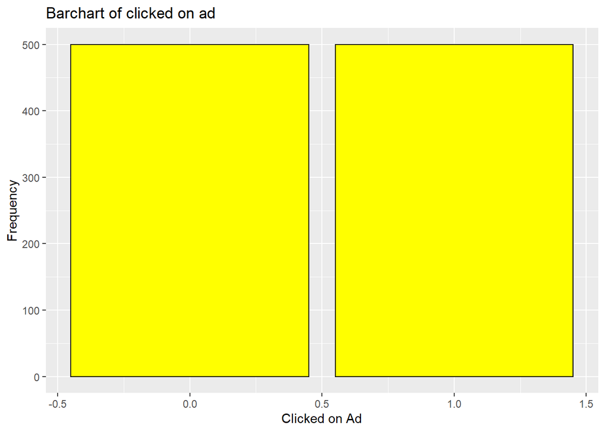

```r
library(ggplot2)

# plot the distribution of clicked on ad
ggplot(dataset, aes(x = Clicked.on.Ad)) +

  geom_bar(fill = "yellow",
           color="black") +


  labs(title = "Barchart of clicked on ad",
       x = "Clicked on Ad",
       y = "Frequency")
```

> There appears to be an equal distribution of people who clicked the add and those who did not.

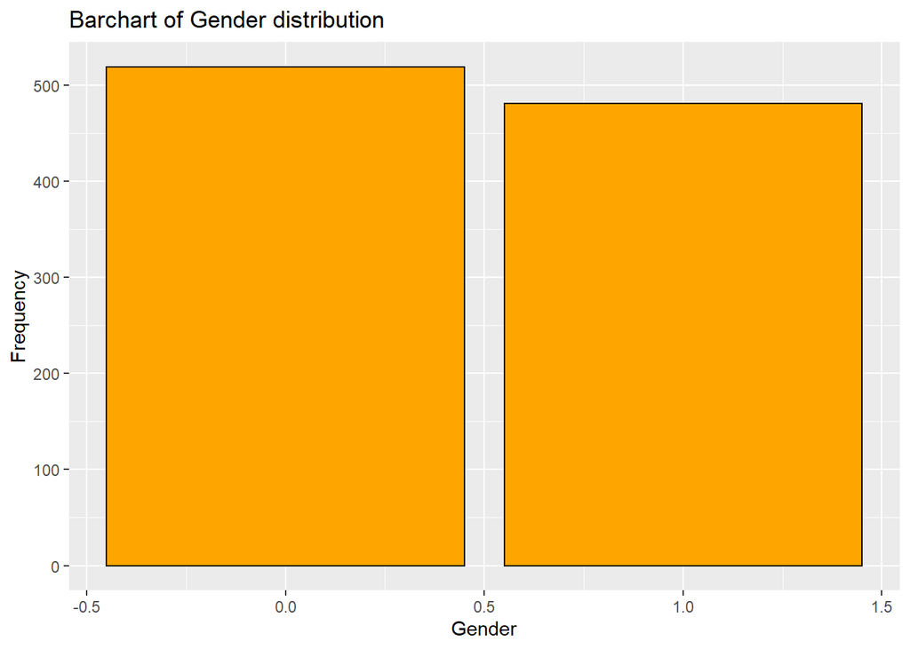

```r
# plot the distribution of Gender
ggplot(dataset, aes(x = Male)) +

  geom_bar(fill = "orange",
           color="black") +
  labs(title = "Barchart of Gender distribution",
       x = "Gender",
       y = "Frequency")
```

> There appears to be more females compared to the Male(0 = represents females while 1 = represents males).

#### BarGraph

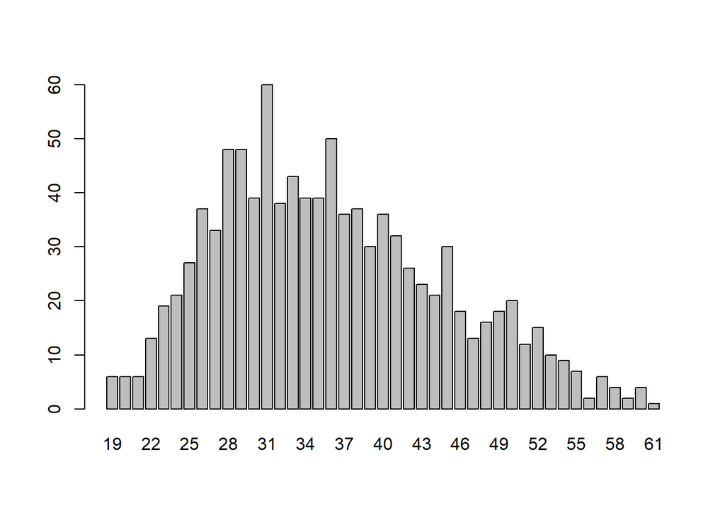

```r
Age_frequency <- table(dataset$Age)
barplot(Age_frequency)
```

> The age of 31 had the highest frequency.

#### Histogram

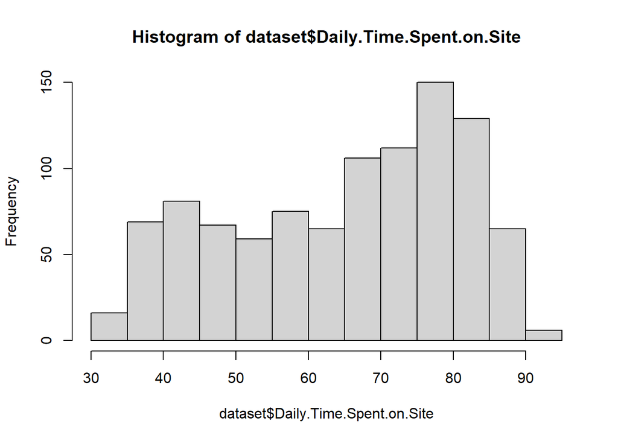

```r
# Histogram of Daily time spent on site
hist(dataset$Daily.Time.Spent.on.Site)
```

> The duration between 75 and 85 had the highest frequency.

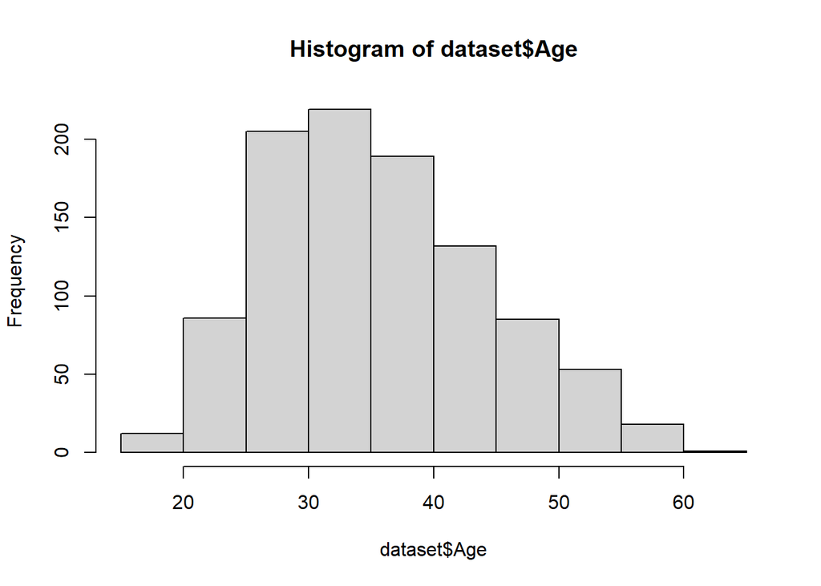

```r
# histogram of age
hist(dataset$Age)
```

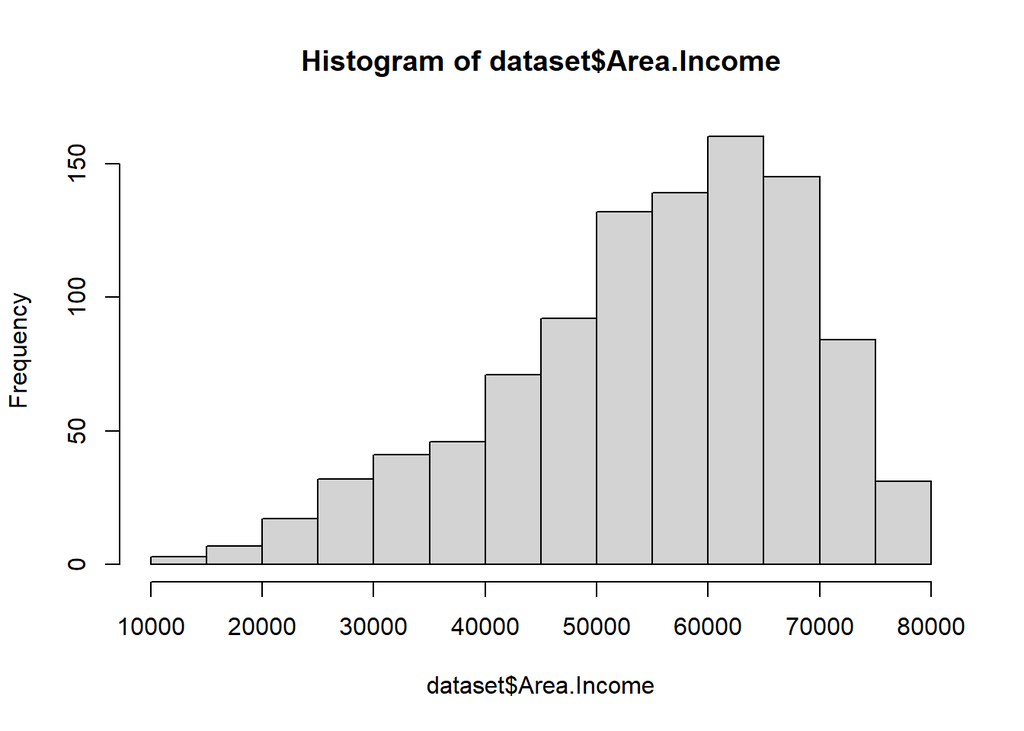

```r
# histogram of Area Income
hist(dataset$Area.Income)
```

> The Area income between 60000 and 70000 had the highest frequency.

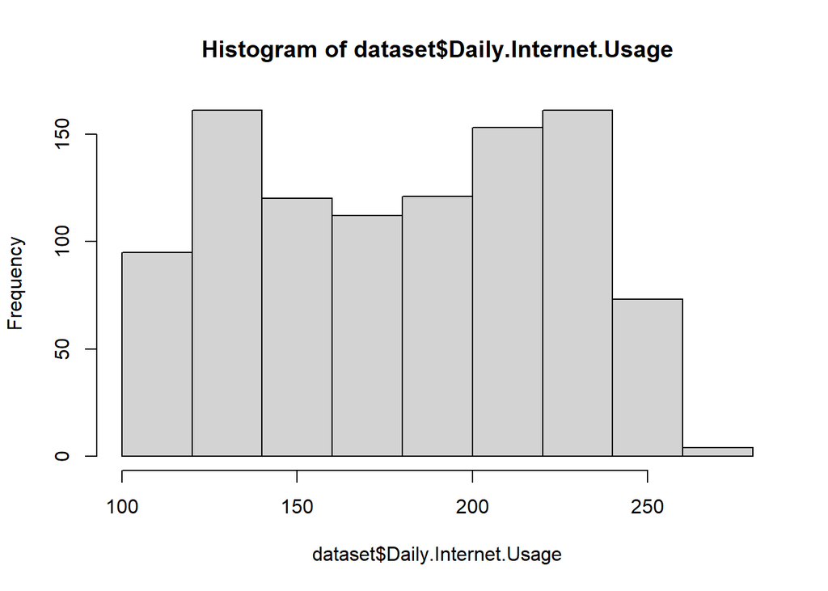

```r
# histogram of daily internet usage
hist(dataset$Daily.Internet.Usage)
```

> The usage between 200 and 250 had the highest frequency consecutively.

# Bivariate and Multivariate Graphical Data Analysis

## 1. Bivariate analysis

#### Covariance

```r
# covariance between daily time spent on site and age
cov(dataset$Daily.Time.Spent.on.Site,dataset$Age)
```

```
## [1] -46.17415
```

> The covariance between daily time spent on site and age is -46.17. It indicates a negative linear relationship between the two variables.

```r
# covariance between area income and daily internet usage
cov(dataset$Area.Income,dataset$Daily.Internet.Usage)
```

```
## [1] 198762.5
```

> The covariance between area income and daily internet usage is 198762.5. It indicates a positive linear relationship between the two variables.

```r
# covariance between daily internet usage and age
cov(dataset$Daily.Internet.Usage,dataset$Age)
```

```
## [1] -141.6348
```

> The covariance between daily internet usage and age is -141.6348. It indicates a negative linear relationship between the two variables.

```r
# covariance between daily time spent on site and area income
cov(dataset$Daily.Time.Spent.on.Site,dataset$Area.Income)
```

```
## [1] 66130.81
```

> The covariance between daily time spent on site and area income is 66130.81 . It indicates a positive linear relationship between the two variables.

#### Correlation Coefficient

```r
# correlation coefficient between area income and daily internet usage
cor(dataset$Area.Income,dataset$Daily.Internet.Usage)
```

```
## [1] 0.3374955
```

> The correlation coefficient between area income and daily internet usage is 0.3375.

```r
# correlation coefficient between daily time spent on site and area income
cor(dataset$Daily.Time.Spent.on.Site,dataset$Area.Income)
```

```
## [1] 0.3109544
```

> The correlation coefficient between daily time spent on site and area income is 0.311.

#### Scatter plot

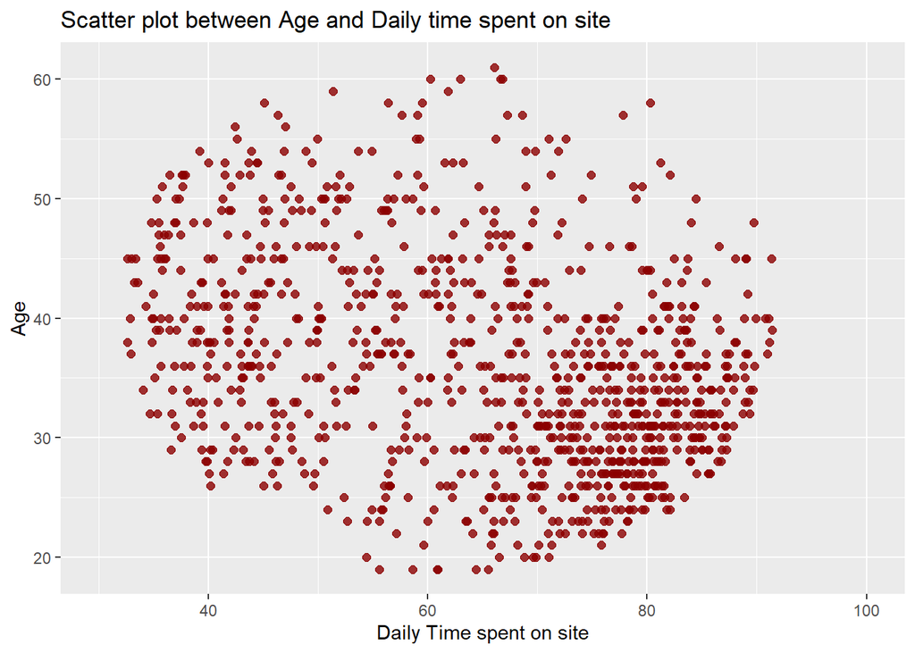

```r
# scatterplot between age and daily time spent on site
ggplot(dataset,

       aes(x = Daily.Time.Spent.on.Site,
           y = Age)) +

  geom_point(color="darkred",
             size = 2,
             alpha=.8) +

  scale_y_continuous(limits = c(19, 61)) +

  scale_x_continuous(limits=c(30, 100)) +

  labs(x = "Daily Time spent on site",

       y = "Age",

       title = "Scatter plot between Age and Daily time spent on site")
```

> The scatter plot of daily time spent on site and age shows us that between the ages 20 years and 40 years spent more time on site.

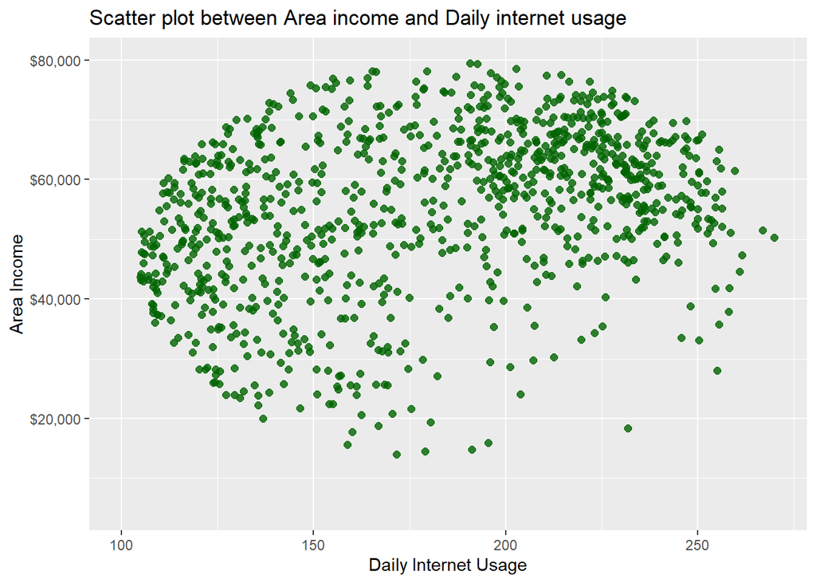

```r
# scatter plot  between area income and daily internet usage
# plot(dataset$Area.Income,dataset$Daily.Internet.Usage, xlab="area income", ylab="daily internet usage")


ggplot(dataset,

       aes(x = Daily.Internet.Usage,
           y = Area.Income)) +

  geom_point(color="darkgreen",
             size = 2,
             alpha=.8) +

  scale_y_continuous(label = scales::dollar,
                     limits = c(5000, 80000)) +

  scale_x_continuous(limits=c(100, 270)) +

  labs(x = "Daily Internet Usage",

       y = "Area Income",

       title = "Scatter plot between Area income and Daily internet usage")
```

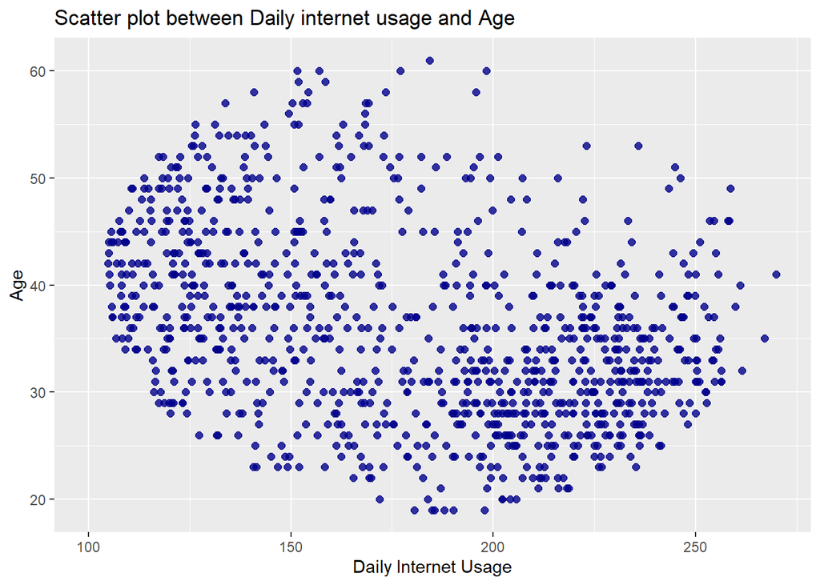

```r
# scatter plot between daily internet usage and age

ggplot(dataset,

       aes(x = Daily.Internet.Usage,
           y = Age)) +

  geom_point(color='darkblue',
             size = 2,
             alpha=.8) +

  scale_y_continuous(limits = c(19, 61)) +

  scale_x_continuous(limits=c(100, 270)) +

  labs(x = "Daily Internet Usage",

       y = "Age",

       title = "Scatter plot between Daily internet usage and Age")
```

> The scatter plot between daily internet usage and age shows us that the age between 20 and 45 years had among the highest daily internet usage.

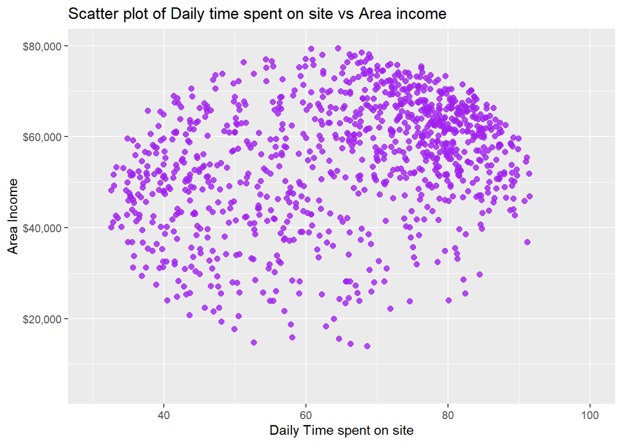

```r
# scatter plot between daily time spent on site and area income

#install.packages("ggplot2", dep=T)
#library(ggplot2)


ggplot(dataset,

       aes(x = Daily.Time.Spent.on.Site,
           y = Area.Income)) +

  geom_point(color="purple",
             size = 2,
             alpha=.8) +

  scale_y_continuous(label = scales::dollar,
                     limits = c(5000, 80000)) +

  scale_x_continuous(limits=c(30, 100)) +

  labs(x = "Daily Time spent on site",

       y = "Area Income",

       title = "Scatter plot of Daily time spent on site vs Area income")
```

### BarChart

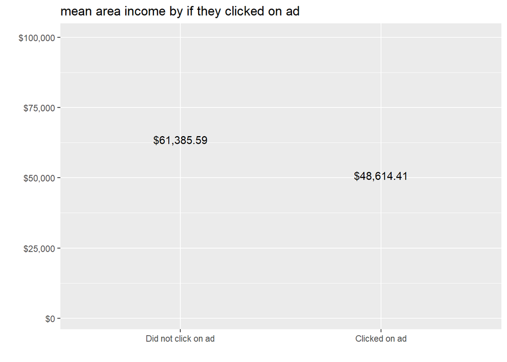

```r
# barchart of Clicked on ad  vs Mean  Area Income

library(dplyr)
library(ggplot2)

plotdata <- dataset %>%
  group_by(Clicked.on.Ad) %>%
  summarize(mean_area_income = mean(Area.Income))

library(scales)
ggplot(plotdata,
       aes(x = factor(Clicked.on.Ad,
                      labels = c("Did not click on ad",
                                 "Clicked on ad")),
                      y = mean_area_income)) +



  geom_text(aes(label = dollar(mean_area_income)),
            vjust = -0.25) +

  scale_y_continuous(limits = c(1000, 100000),
                     label = dollar) +
  labs(title = "mean area income by if they clicked on ad",
       x = "",
       y = "")
```

> From our plot the people who had a lesser mean area income were the ones who clicked on the ad while the people who had higher mean area income did not really click on the ads.

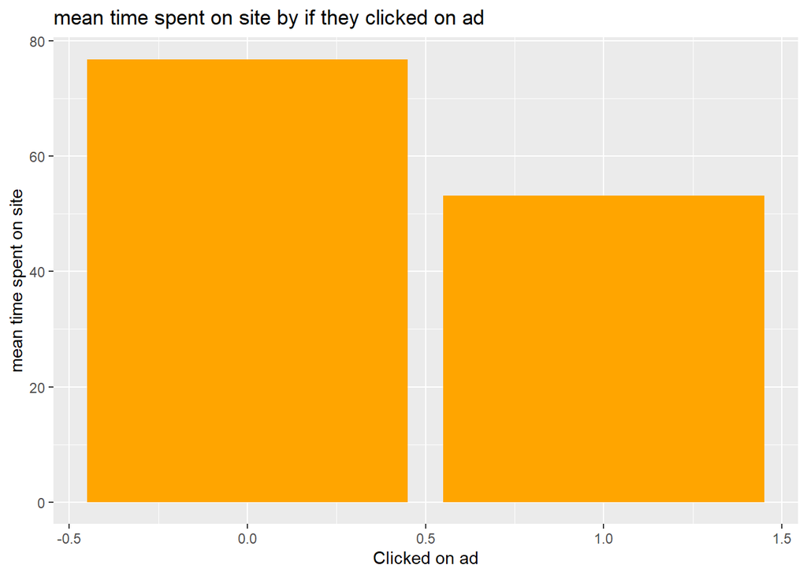

```r
# barchart of mean time spent on site vs clicked on ad
library(dplyr)
plotdata <- dataset %>%
  group_by(Clicked.on.Ad) %>%
  summarize(mean_time_spent_on_site = mean(Daily.Time.Spent.on.Site))

# plot mean salaries
ggplot(plotdata,
       aes(x = Clicked.on.Ad,
           y = mean_time_spent_on_site)) +
  geom_bar(stat = "identity",
           fill = "orange")+
  labs(title = "mean time spent on site by if they clicked on ad",
       x = "Clicked on ad",
       y = "mean time spent on site")
```

> From the plot it is likely that the people who spent less time on the site are likely to have clicked on the ads while those who spent more time did not click on the ads.

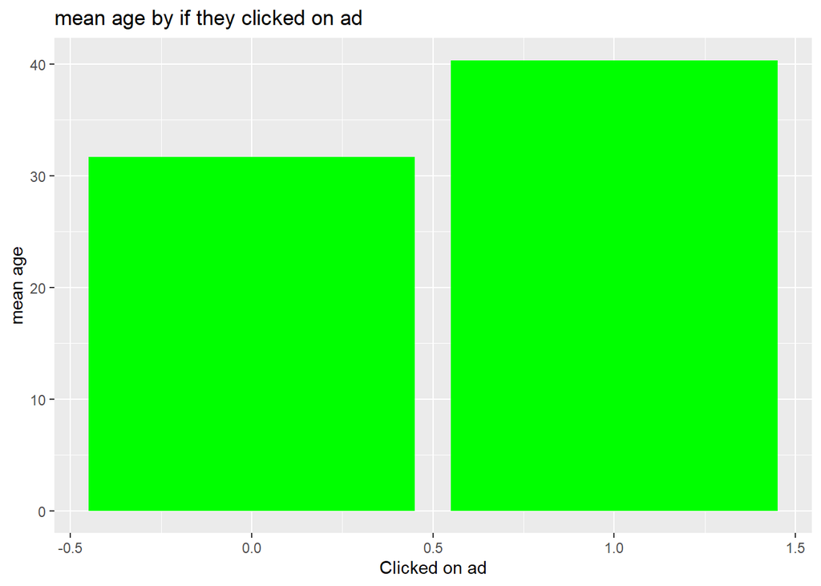

```r
# bar chart of mean age vs clicked on ad
plotdata <- dataset %>%
  group_by(Clicked.on.Ad) %>%
  summarize(mean_age = mean(Age))

# plot mean salaries
ggplot(plotdata,
       aes(x = Clicked.on.Ad,
           y = mean_age)) +
  geom_bar(stat = "identity",
           fill = "green")+
  labs(title = "mean age by if they clicked on ad",
       x = "Clicked on ad",
       y = "mean age")
```

> From our plot it is evident that those with a mean age of around 40years were likely to click on the ad compared to the ones below that mean age.

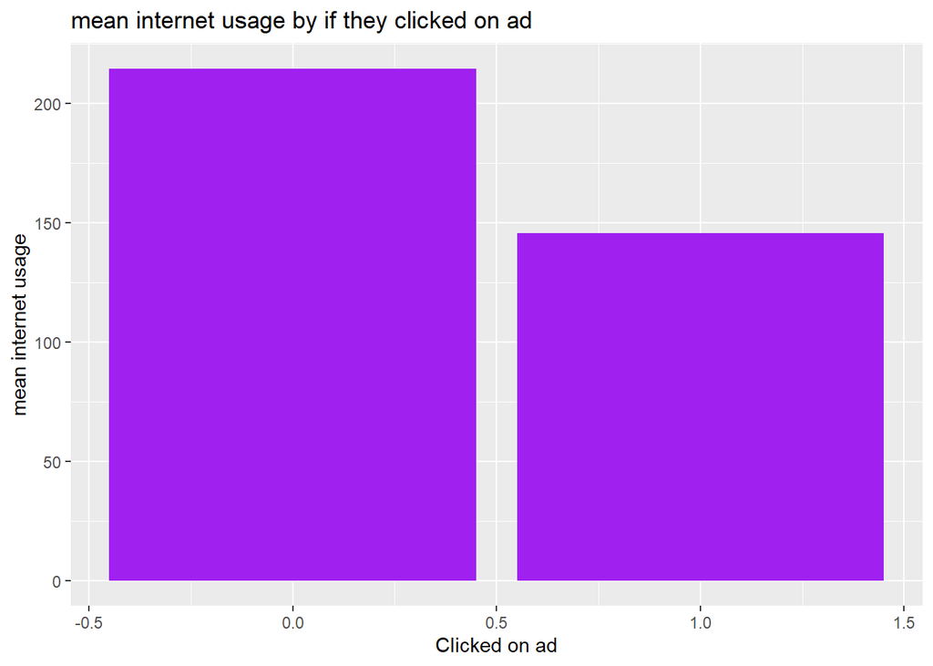

```r
# bar chart of mean internet usage vs clicked on ad
plotdata <- dataset %>%
  group_by(Clicked.on.Ad) %>%
  summarize(mean_internet_usage = mean(Daily.Internet.Usage))

# plot mean salaries
ggplot(plotdata,
       aes(x = Clicked.on.Ad,
           y = mean_internet_usage)) +
  geom_bar(stat = "identity",
           fill = "purple")+
  labs(title = "mean internet usage by if they clicked on ad",
       x = "Clicked on ad",
       y = "mean internet usage")
```

> From our plot it is evident that the people who spent more time on the internet were less likely to click on the >ads compared to those who spent little time on the internet.

##### Conclusions and Recommendations

> From our analysis we found that the people who had a lower area income rate are the ones who were most likely to have clicked on the ads meaning they were captivated by the online cryptography course which maybe would be an ideal way for them to increase their incomes.

> We have also established that the people who spent more time on the site were less likely to have clicked on the ads compared to those who spent less time on the site which could be the new people to the blog site thus the online cryptography course would be ideal to new site visitors.

> In addition the people with mean age of above 40 years old were likely to have clicked on the ads compared to the population with the mean age of 31 years and below. This means that the online cryptography course would be more marketable to the mean age group of 40 years of the population on site.

> Lastly we have seen from our analysis that the mean of the people who had high internet usage were less likely to have clicked on the ads compared to the ones who had low internet usage thus it would be better for the entrepreneur to focus on a more captivating ad which would appeal to the people who had high internet usage to click on the ads.